# ML5

Wytze Vlietstra

12/15/2017

# Introduction

Based on the face-to-face meeting we had on 14-12-2017 in Leiden, it was agreed upon that several additional experiments would be executed. First, performance will be measured when either the count features, or the diversity features are used. Second, the strict separation of training and the test set described in ML4 will be repeated, but now the drug-disease combinations will be separated, or just the diseases. Finally, the classification will be performed several times, where it is checked which combinations are consistently misclassified, and why.

Additionally, the end dates of the clinical trials for the negative cases in RepoDB are retrieved from clinicaltrials.gov, and analysed. Finally, some analyses are performed on RepoDB itself.

# Experiments

## Load in the data

```r
require(caret)
require(randomForest)
require(plyr)
require(dplyr)
require(ggplot2)
require(pROC)
require(doMC)
registerDoMC(cores = 22)

# Columns which should not be used for classification
exclusion_columns = c("Drug", "Disease", "Drugbank.ID", "Disease.ID", "drug_ids", "disease_ids", "goldstandard")

# Create the positive set
count_pos = read.csv("~/pRojects/Tareq/Datasets 2/count_pos.csv", stringsAsFactors = F)
diversity_pos = read.csv("~/pRojects/Tareq/Datasets 2/diversity_pos.csv", stringsAsFactors = F)
pos = merge(count_pos, diversity_pos, by = intersect(colnames(count_pos), colnames(diversity_pos)))
pos$goldstandard = "VALID"

# Create the negative set
count_neg = read.csv("~/pRojects/Tareq/Datasets 2/count_neg.csv", stringsAsFactors = F)
diversity_neg = read.csv("~/pRojects/Tareq/Datasets 2/diversity_neg.csv", stringsAsFactors = F)
neg = merge(count_neg, diversity_neg, by = intersect(colnames(count_neg), colnames(diversity_neg)))
neg$goldstandard = "INVALID"

all = rbind.fill(pos, neg)
all[is.na(all)] = 0

pos[is.na(pos)] = 0
neg[is.na(neg)] = 0

# Some columns are empty, meaning their sum is 0. Others are not relevant as features. These are also removed
all$direct = as.logical(all$direct)
goldstandard = factor(all$goldstandard, levels = c("VALID", "INVALID"))
```

## Classify count and diversity features separately from each other

### Count features

```r
count_gs = factor(c(rep("VALID", nrow(count_pos)), rep("INVALID", nrow(count_neg))), levels = c("VALID", "INVALID"))

counts_all = rbind.fill(count_pos, count_neg)
counts_all = counts_all[,-which(colnames(counts_all) %in% exclusion_columns)]
counts_all[is.na(counts_all)] = 0
counts_all$direct = ifelse(counts_all$direct == "True", T, F)

counts_model =  train(x = counts_all, y = count_gs, method = "rf",
              trControl=trainControl(method="cv", number = 10, classProbs = TRUE,
              savePredictions = TRUE, summaryFunction = twoClassSummary),
              prox=TRUE, allowParallel=TRUE, metric = "ROC")

kable(counts_model$results[counts_model$results$mtry == counts_model$bestTune$mtry, c("ROC", "Sens", "Spec")], row.names = F)
```

| ROC | Sens | Spec |
| --- | --- | --- |
| 0.8695358 | 0.9612818 | 0.6549689 |

As can be seen, performance decreases somewhat, but not drastically. Especially the negative cases, i.e. the specificity appear to perform lower.

### Diversity features

```r
diversity_gs = c(rep("VALID", nrow(diversity_pos)), rep("INVALID", nrow(diversity_neg)))

diversity_all = rbind.fill(diversity_pos, diversity_neg)
diversity_all = diversity_all[,-which(colnames(diversity_all) %in% exclusion_columns)]
diversity_all[is.na(diversity_all)] = 0
diversity_all$direct = ifelse(diversity_all$direct == "True", T, F)

diversity_model =  train(x = diversity_all, y = diversity_gs, method = "rf",
              trControl=trainControl(method="cv", number = 10, classProbs = TRUE,
              savePredictions = TRUE, summaryFunction = twoClassSummary),
              prox=TRUE, allowParallel=TRUE, metric = "ROC")

kable(diversity_model$results[diversity_model$results$mtry == diversity_model$bestTune$mtry, c("ROC", "Sens", "Spec")], row.names = F)
```

| ROC | Sens | Spec |
| --- | --- | --- |
| 0.8414622 | 0.3123571 | 0.9743641 |

Here, performance is also lower, similar to the performance of the count features. What is interesting here, is that the specificity is a lot higher than the sensitivity. It appears that the counts and the diversity features therefore have a different function.

The count features can be used to identify the positive cases, and the diversity features can be used to identify the negative cases.

## Classify with a strict separation between training and test set

### Diseases

```r
exclusion_columns = c("Drug", "Disease", "Drugbank.ID", "Disease.ID", "drug_ids", "disease_ids", "goldstandard")
diseases = unique(all$Disease)

# List all drugs, and split them up in non-overlapping partitions
nFolds = 10
folds = createFolds(diseases, nFolds)

outcomes = data.frame(fold = seq(1, nFolds), ROC = NA, Sensitivity = NA, Specificity = NA, ratio_training = NA, ratio_test = NA)

for(i in 1:nFolds){
  test_set = all[which(all$Disease %in% diseases[folds[i][[1]]]), ]
  training_set = all[which(!all$Disease %in% diseases[folds[i][[1]]]), ]
  training_set_gs = training_set$goldstandard
  training_set = training_set[,-which(colnames(training_set) %in% exclusion_columns)]
  training_distribution = table(training_set_gs)
  outcomes$ratio_training[i] = training_distribution["VALID"] / training_distribution["INVALID"]
  test_distribution = table(test_set$goldstandard)
  outcomes$ratio_test[i] = test_distribution["VALID"] / test_distribution["INVALID"]

  cv_model =  train(x = training_set, y = training_set_gs, method = "rf",
              trControl=trainControl(method="none", classProbs = TRUE,
              savePredictions = TRUE, summaryFunction = twoClassSummary),
              prox=TRUE, allowParallel=TRUE, metric = "ROC")

  predictions = predict(cv_model, test_set, type = "prob")
  predictions$binary = ifelse(predictions$VALID > 0.5, "VALID", "INVALID")
  outcomes$ROC[i] = as.numeric(roc(test_set$goldstandard, predictions$VALID)$auc)
  confMat = confusionMatrix(predictions$binary, test_set$goldstandard, positive = "VALID")
  outcomes[i, c("Sensitivity", "Specificity")] = confMat$byClass[c("Sensitivity", "Specificity")]

}
  outcomes = rbind(outcomes, c("Mean", apply(outcomes[,c("ROC", "Sensitivity", "Specificity", "ratio_training", "ratio_test")], 2, mean)))
  outcomes[,-1] = data.frame(lapply(outcomes[,-1], function(y) round(as.numeric(y), 3)))

  kable(outcomes)
```

| fold | ROC | Sensitivity | Specificity | ratio_training | ratio_test |
| --- | --- | --- | --- | --- | --- |
| 1 | 0.950 | 0.945 | 0.753 | 2.009 | 3.416 |
| 2 | 0.937 | 0.953 | 0.686 | 2.069 | 2.250 |
| 3 | 0.934 | 0.965 | 0.708 | 2.074 | 2.225 |
| 4 | 0.954 | 0.959 | 0.751 | 2.003 | 3.154 |
| 5 | 0.952 | 0.922 | 0.789 | 2.266 | 1.128 |
| 6 | 0.947 | 0.954 | 0.733 | 2.018 | 3.102 |
| 7 | 0.941 | 0.955 | 0.723 | 2.058 | 2.355 |
| 8 | 0.931 | 0.935 | 0.710 | 2.256 | 1.269 |
| 9 | 0.946 | 0.940 | 0.795 | 2.146 | 1.441 |
| 10 | 0.931 | 0.939 | 0.746 | 2.021 | 2.810 |
| Mean | 0.942 | 0.947 | 0.739 | 2.092 | 2.315 |

Carefully separating the diseases between the training and the test set appears to barely influence performance, similar to the careful separation of drugs between the training and the test set.

### Drug-disease combinations

```r
exclusion_columns = c("Drug", "Disease", "Drugbank.ID", "Disease.ID", "drug_ids", "disease_ids", "goldstandard")
diseases = unique(all$Disease)

# List all drugs, and split them up in non-overlapping partitions
nFolds = 10
folds = createFolds(diseases, nFolds)

outcomes = data.frame(fold = seq(1, nFolds), ROC = NA, Sensitivity = NA, Specificity = NA, ratio_training = NA, ratio_test = NA, nrow_training = NA, nrow_test = NA)

for(i in 1:nFolds){
  test_set = all[which(all$Disease %in% diseases[folds[i][[1]]]), ]
  training_set = all[which(!all$Disease %in% diseases[folds[i][[1]]]), ] # Remove the diseases
  training_set = training_set[which(!training_set$Drug %in% test_set$Drug), ] # Remove their indications
  training_set_gs = training_set$goldstandard
  training_set = training_set[,-which(colnames(training_set) %in% exclusion_columns)]
  training_distribution = table(training_set_gs)
  outcomes$ratio_training[i] = training_distribution["VALID"] / training_distribution["INVALID"]
  test_distribution = table(test_set$goldstandard)
  outcomes$ratio_test[i] = test_distribution["VALID"] / test_distribution["INVALID"]

  cv_model =  train(x = training_set, y = training_set_gs, method = "rf",
              trControl=trainControl(method="none", classProbs = TRUE,
              savePredictions = TRUE, summaryFunction = twoClassSummary),
              prox=TRUE, allowParallel=TRUE, metric = "ROC")

  predictions = predict(cv_model, test_set, type = "prob")
  predictions$binary = ifelse(predictions$VALID > 0.5, "VALID", "INVALID")
  outcomes$ROC[i] = as.numeric(roc(test_set$goldstandard, predictions$VALID)$auc)
  confMat = confusionMatrix(predictions$binary, test_set$goldstandard, positive = "VALID")
  outcomes[i, c("Sensitivity", "Specificity")] = confMat$byClass[c("Sensitivity", "Specificity")]
  outcomes$nrow_training[i] = nrow(training_set)
  outcomes$nrow_test[i] = nrow(test_set)

}
  outcomes = rbind(outcomes, c("Mean", apply(outcomes[,c("ROC", "Sensitivity", "Specificity", "ratio_training", "ratio_test", "nrow_training", "nrow_test")], 2, mean)))
  outcomes[,-1] = data.frame(lapply(outcomes[,-1], function(y) round(as.numeric(y), 3)))

  kable(outcomes)
```

| fold | ROC | Sensitivity | Specificity | ratio_training | ratio_test | nrow_training | nrow_test |
| --- | --- | --- | --- | --- | --- | --- | --- |
| 1 | 0.859 | 0.965 | 0.415 | 4.217 | 2.481 | 1946.0 | 839.0 |
| 2 | 0.883 | 0.956 | 0.491 | 4.702 | 1.633 | 2161.0 | 998.0 |
| 3 | 0.929 | 0.965 | 0.702 | 3.398 | 2.187 | 2199.0 | 835.0 |
| 4 | 0.849 | 0.932 | 0.500 | 2.677 | 3.397 | 2416.0 | 765.0 |
| 5 | 0.896 | 0.954 | 0.632 | 3.056 | 2.713 | 2113.0 | 917.0 |
| 6 | 0.901 | 0.972 | 0.475 | 4.111 | 1.929 | 1973.0 | 870.0 |
| 7 | 0.896 | 0.967 | 0.582 | 3.193 | 2.658 | 2931.0 | 673.0 |
| 8 | 0.867 | 0.949 | 0.540 | 3.658 | 2.460 | 2301.0 | 775.0 |
| 9 | 0.903 | 0.959 | 0.591 | 3.836 | 1.659 | 2186.0 | 859.0 |
| 10 | 0.928 | 0.969 | 0.615 | 3.946 | 1.210 | 2562.0 | 833.0 |
| Mean | 0.891 | 0.959 | 0.554 | 3.679 | 2.233 | 2278.8 | 836.4 |

Here there appears to be a bit more variability in the performance. This might be caused by the smaller training set, which is around a third of its regular size. However, the drop in performance is still not something to be worried about, with a mean around the 90%.

## Identify instances which are consistently misclassified for an error analysis

To check which instances are consistently misclassified, we perform 10 classifications, for each of which we check which instances are misclassified. I set the cutoff at 9/10, but both this cutoff and the number of classifications can be varied. I do not explicitly set the seed to vary it, because I assume R does a good job of varying that by itself for every run.

```r
nClassifications = 10
misclassifiedCutoff = 9

classification_frame = cbind(all[,c("Drug", "Disease")], goldstandard = goldstandard, rowIndex = 1:nrow(all))

feature_set = all[,-which(colnames(all) %in% exclusion_columns)]

for(i in 1:nClassifications){
  misclassified_model =  train(x = feature_set, y = goldstandard, method = "rf",
                         trControl=trainControl(method="cv", number = 10, classProbs = TRUE,
                         savePredictions = TRUE, summaryFunction = twoClassSummary),
                         prox=TRUE, allowParallel=TRUE, metric = "ROC")

  predictions = misclassified_model$pred[misclassified_model$pred$mtry == misclassified_model$bestTune$mtry,]
  predictions[,paste("class",i, sep ="")] = ifelse(predictions$pred == predictions$obs, 0, 1)
  classification_frame = merge(classification_frame, predictions[,c("rowIndex", paste("class",i, sep =""))], by = "rowIndex")
}
classification_frame$errorSum = rowSums(classification_frame[,5:ncol(classification_frame)])

kable(classification_frame[classification_frame$errorSum >= misclassifiedCutoff, c("Drug", "Disease", "goldstandard")], row.names = F)
```

| Drug | Disease | goldstandard |
| --- | --- | --- |
| Acetylsalicylic acid | Pain | VALID |
| Afatinib | Epidermal growth factor receptor positive non-small cell lung cancer | VALID |
| Amobarbital | Severe anxiety (panic) | VALID |
| Amoxicillin | Pneumonia due to Staphylococcus aureus | VALID |
| Arsenic trioxide | Acute Promyelocytic Leukemia | VALID |
| Azelastine | Rhinitis, Vasomotor | VALID |
| Benzylpenicillin | Infection by Pasteurella multocida | VALID |
| Biperiden | Parkinson Disease | VALID |
| Carboplatin | Malignant neoplasm of ovary | VALID |
| Cariprazine | Bipolar affective disorder, current episode manic | VALID |
| Cefepime | PYELONEPHRITIS E COLI | VALID |
| Cefprozil | Infection of skin AND/OR subcutaneous tissue | VALID |
| Ceftizoxime | Acute gonococcal endometritis | VALID |
| Cefuroxime | Acute gonococcal cervicitis | VALID |
| Cefuroxime | Rhinoscleroma | VALID |
| Cefuroxime | Streptococcal meningitis | VALID |
| Clavulanate | Sepsis due to Pseudomonas | VALID |
| Cloxacillin | Staphylococcus aureus infection | VALID |
| Colchicine | Gout | VALID |
| Corticotropin | Stevens-Johnson Syndrome | VALID |
| Cromoglicic acid | Keratoconjunctivitis, Vernal | VALID |
| Cyclizine | Allergic rhinitis (disorder) | VALID |
| Dactinomycin | Nephroblastoma | VALID |
| Dasatinib | Leukemia, Myeloid, Accelerated Phase | VALID |
| Desonide | Chronic small plaque psoriasis | VALID |
| Dexamethasone | Cooley’s anemia | VALID |
| Dexamethasone | Crohn Disease | VALID |
| Dexamethasone | Lichen Simplex Chronicus | VALID |
| Dexamethasone | Psoriasis | VALID |
| Dexamethasone | Punctate keratopathy | VALID |

[output cut: 671 more lines]

## A deeper dive into why these cases are misclassified

As described above, the set of instances which are consistently misclassified is fairly stable. Here, I will try to identify why these instances are so consistently misclassified. I will do that by first examining the features themselves, to examine how these differ from the correctly identified positive and negative cases. For the negative cases, I will also look at the RepoDB data, to examine whether these cases all have a very specific reason in common why the trial failed.

I will also look at the individual drugs and diseases, and examine whether a specific drug or a specific disease is more often misclassified than purely by chance.

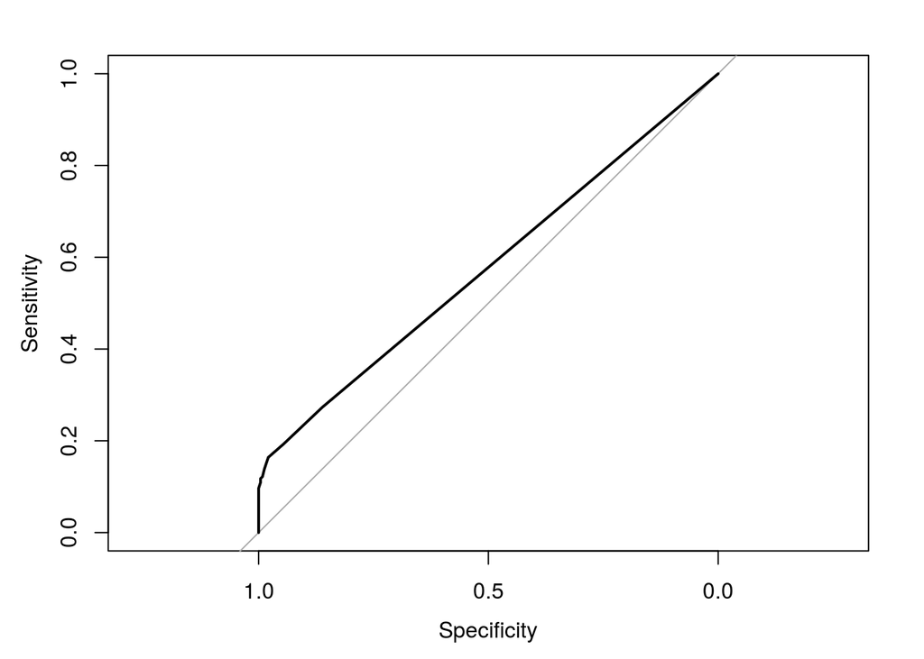

```r
# Extract the positive cases from the misclassifieds
FN = merge(classification_frame[classification_frame$goldstandard == "VALID" &
                                           classification_frame$errorSum >= misclassifiedCutoff, c("Drug", "Disease")],
                      all, by.x = c("Drug", "Disease"), by.y = c("Drug", "Disease"), all.x = T)
FN$goldstandard = "INVALID"

# Sample an equally sized number of positive cases which are consistenly classified correctly
TP = merge(classification_frame[classification_frame$goldstandard == "VALID" &
                                           classification_frame$errorSum <= 1, c("Drug", "Disease")],
                        all, by.x = c("Drug", "Disease"), by.y = c("Drug", "Disease"), all.x = T)
TP = TP[sample(row.names(TP), nrow(FN)),]

positiveCases_all = rbind(FN, TP)
pos_gs = factor(positiveCases_all$goldstandard)
positiveCases_all = positiveCases_all[,-which(colnames(positiveCases_all) %in% exclusion_columns)]

positive_misclassified =  train(x = positiveCases_all, y = pos_gs, method = "rf",
                         trControl=trainControl(method="cv", number = 10, classProbs = TRUE,
                         savePredictions = TRUE, summaryFunction = twoClassSummary),
                         prox=TRUE, allowParallel=TRUE, metric = "ROC")

pos_importances = data.frame(name = rownames(varImp(positive_misclassified)$importance),
                             varImp(positive_misclassified)$importance)
pos_importances = pos_importances[order(-pos_importances$Overall),]

# Plot roc curves of the two most predictive features
plot(roc(pos_gs, positiveCases_all[,pos_importances$name[1]]))
```

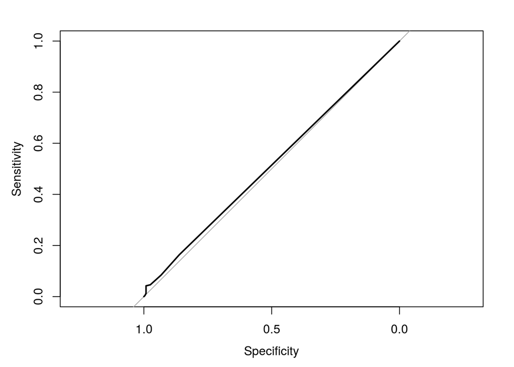

```r
plot(roc(pos_gs, positiveCases_all[,pos_importances$name[2]]))
```

```r
# What is the mean value of the most important feature between the misclassifieds, and the true negatives?
TN = unique(merge(classification_frame[classification_frame$goldstandard == "INVALID" &
                                           classification_frame$errorSum <= 1, c("Drug", "Disease")],
                        all, by.x = c("Drug", "Disease"), by.y = c("Drug", "Disease"), all.x = T))

# Are the mean differences between the TP/FN closer than the FN/TN?
# TN comparison for most important feature
mean(FN[,pos_importances$name[1]]) - mean(TN[,pos_importances$name[1]])
```

```
## [1] 0.1937268
```

```r
# TP comparison for most important feature
mean(FN[,pos_importances$name[1]]) - mean(TP[,pos_importances$name[1]])
```

```
## [1] 0.7689076
```

```r
# TN comparison for second most important feature
mean(FN[,pos_importances$name[2]]) - mean(TN[,pos_importances$name[2]])
```

```
## [1] -0.004833032
```

```r
# TP comparison for second most important feature
mean(FN[,pos_importances$name[2]]) - mean(TP[,pos_importances$name[2]])
```

```
## [1] 0.004201681
```

The ROC curves don’t differ very much, and do not show a drastic difference between the consistently correctly classified instances, and the consistently misclassified instances. Comparing the mean differences between the TP, FN, and TN cases provides a mixed result. You would expect the TN and FN’s are alike, so a smaller mean difference when comparing these than the TP and FN. However, this is only the case for one of the two most important features, i.e. the first one. For the second one, the mean difference between the TP and the FN is actually smaller. This is puzzling. However, for now I won’t dive deeper into this.

Next, I examine the negative cases, and see whether there is a common reason for the clinical trial to be failed which is associated with the misclassification.

```r
repoDB = read.csv("RepoDB.csv", stringsAsFactors = F)

neg_misclassifieds = merge(classification_frame[classification_frame$goldstandard == "INVALID" &
                                                classification_frame$errorSum >= misclassifiedCutoff, c("Drug", "Disease")],
                           repoDB[,c("drug_name", "ind_name", "DetailedStatus")],
                           by.x = c("Drug", "Disease"), by.y = c("drug_name", "ind_name"))
misclassifieds_termination_reasons = as.data.frame(table(neg_misclassifieds$DetailedStatus))
kable(misclassifieds_termination_reasons[order(-misclassifieds_termination_reasons$Freq)[1:25], ], row.names = F)
```

| Var1 | Freq |
| --- | --- |
|  | 175 |
| Administratively complete. | 41 |
| Low accrual | 16 |
| Slow accrual | 11 |
| Lack of funding | 10 |
| Poor accrual | 9 |
| Inadequate accrual rate | 7 |
| low accrual | 7 |
| Major revisions needed in study | 7 |
| The study was stopped due to the inability to determine an acceptable dose with the potential for further study | 6 |
| Discontinued development of G3139 (oblimersen) | 5 |
| Due to a lack of funding | 5 |
| due to safety concerns and lack of efficacy | 5 |
| MTD not determined | 5 |
| The study was terminated prematurely due to slow accrual. | 5 |
| This study was closed early by the DSMB due to increased toxicity. | 5 |
| Data Safety Monitoring Board (DSMB) recommended stopping study due to futility | 4 |
| Due to Slow Accrual study was terminated. | 4 |
| Funding unavailable | 4 |
| No Funding Source and Competing Trials | 4 |
| slow accrual | 4 |
| Sponsor withdrew support; Study did not progress to Phase II. | 4 |
| Sponsor withdrew support; Study did not progress to Phase II (Phase I registration NCT00895960) | 4 |
| Study was terminated due to inability to recruit enough patients that meet inclusion criteria. No analysis will be done. | 4 |
| Unacceptable morbidity & mortality | 4 |

While the majority of the termination reasons look similar as the overall termination reasons, the top 25 appear to contain more toxicity and adverse event reasons than overall (See below). I’m not sure how to interpret this, because some anti-cancer drugs are tested for every phase (I-IV) of the same disease, as could be seen above. For now, I will not further investigate the frequency with which this occurs.

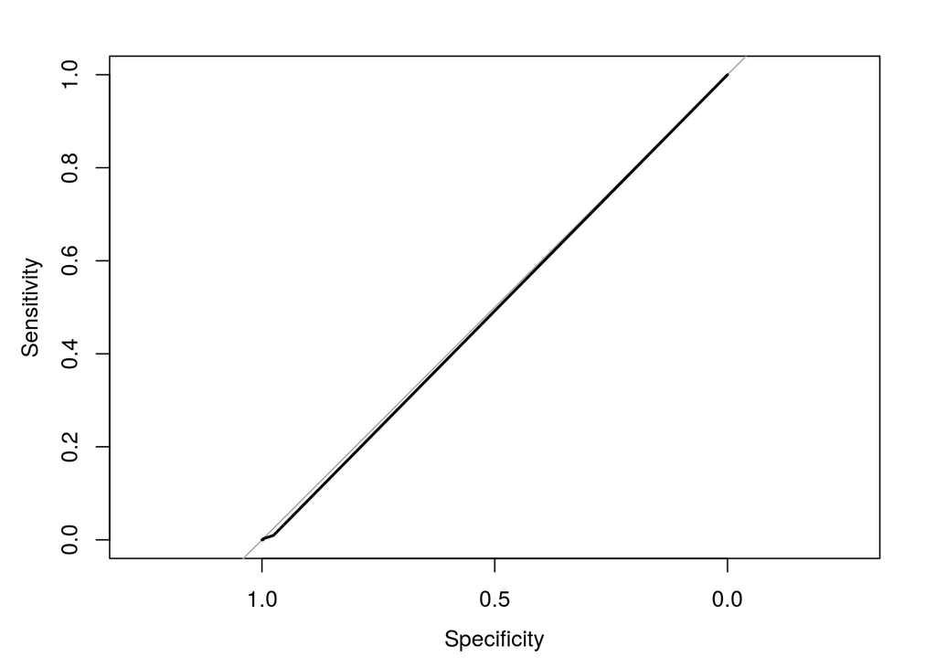

```r
# Extract the positive cases from the misclassifieds
FP = merge(classification_frame[classification_frame$goldstandard == "INVALID" &
                                           classification_frame$errorSum >= misclassifiedCutoff, c("Drug", "Disease")],
                      all, by.x = c("Drug", "Disease"), by.y = c("Drug", "Disease"), all.x = T)
FP$goldstandard = "VALID"

# Sample an equally sized number of negative cases which are consistenly classified correctly
TN = merge(classification_frame[classification_frame$goldstandard == "INVALID" &
                                           classification_frame$errorSum <= 1, c("Drug", "Disease")],
                        all, by.x = c("Drug", "Disease"), by.y = c("Drug", "Disease"), all.x = T)
negativeCases_control = TN[sample(row.names(TN), nrow(FP)),]

negativeCases_all = rbind(FP, TN)
neg_gs = factor(negativeCases_all$goldstandard)
negativeCases_all = negativeCases_all[,-which(colnames(negativeCases_all) %in% exclusion_columns)]

negative_misclassified =  train(x = negativeCases_all, y = neg_gs, method = "rf",
                         trControl=trainControl(method="cv", number = 10, classProbs = TRUE,
                         savePredictions = TRUE, summaryFunction = twoClassSummary),
                         prox=TRUE, allowParallel=TRUE, metric = "ROC")

neg_importances = data.frame(name = rownames(varImp(negative_misclassified)$importance),
                             varImp(negative_misclassified)$importance)
neg_importances = neg_importances[order(-neg_importances$Overall),]

# Plot roc curves of the two most predictive features
plot(roc(neg_gs, negativeCases_all[,neg_importances$name[1]]))
```

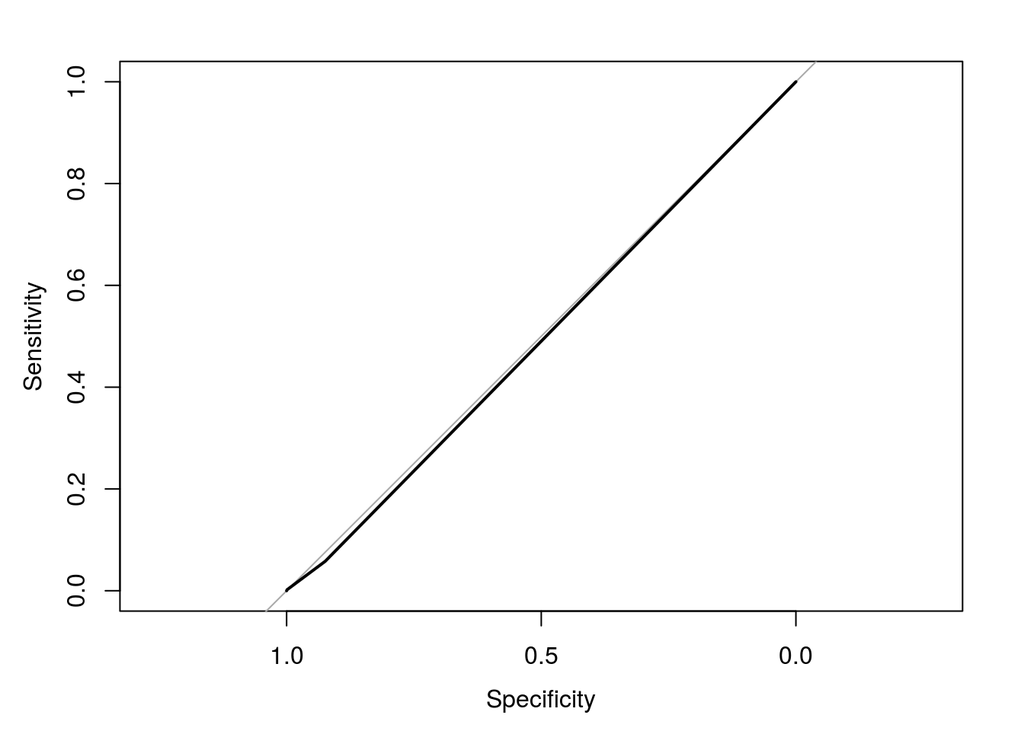

```r
plot(roc(neg_gs, negativeCases_all[,neg_importances$name[2]]))
```

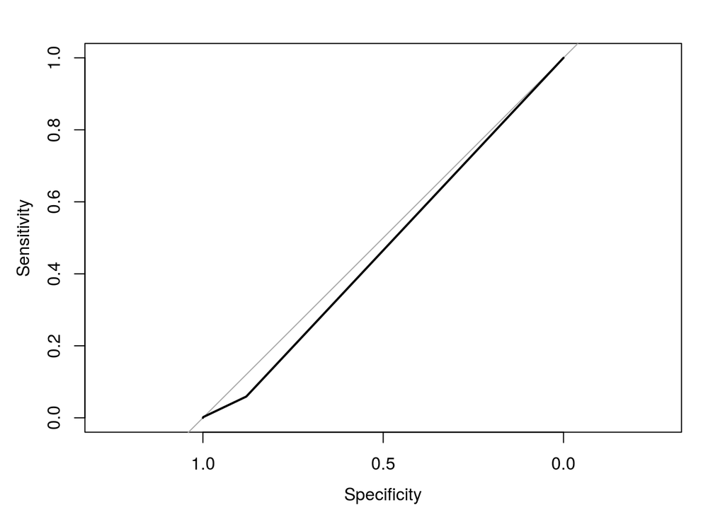

```r
plot(roc(neg_gs, negativeCases_all[,neg_importances$name[3]]))
```

```r
# What is the mean value of the most important feature between the misclassifieds, and the true negatives?
TP = unique(merge(classification_frame[classification_frame$goldstandard == "VALID" &
                                           classification_frame$errorSum <= 1, c("Drug", "Disease")],
                        all, by.x = c("Drug", "Disease"), by.y = c("Drug", "Disease"), all.x = T))

# Are the mean differences between the TN/TP closer than the TN/FN?
# TP comparison for most important feature
mean(FP[,neg_importances$name[1]]) - mean(TP[,neg_importances$name[1]])
```

```
## [1] 0.3859191
```

```r
# TN comparison for most important feature
mean(FP[,neg_importances$name[1]]) - mean(TN[,neg_importances$name[1]])
```

```
## [1] 0.08134972
```

```r
# TP comparison for second most important feature
mean(FP[,neg_importances$name[2]]) - mean(TP[,neg_importances$name[2]])
```

```
## [1] 3.295953
```

```r
# TN comparison for second most important feature
mean(FP[,neg_importances$name[2]]) - mean(TN[,neg_importances$name[2]])
```

```
## [1] -4.59328
```

```r
# TP comparison for third most important feature
mean(FP[,neg_importances$name[3]]) - mean(TP[,neg_importances$name[3]])
```

```
## [1] 0.0364933
```

```r
# TN comparison for third most important feature
mean(FP[,neg_importances$name[3]]) - mean(TN[,neg_importances$name[3]])
```

```
## [1] 0.05106696
```

I find it very difficult to identify why these features are identified as the most important, and how this classification actually works. Perhaps a topic for further discussion?

### Classification performance of individual drugs and diseases

We compare the probability that the drug or disease is in this set by coincidence, and compare it with its actual frequency. Based on that, I show the most imbalanced drugs/diseases.

```r
# First, calculate the frequency of the drugs and the diseases in the complete dataset, separated for positive and negative cases
accepted_drugs = as.data.frame(table(repoDB[repoDB$status == "Approved", "drug_name"]))
accepted_diseases = as.data.frame(table(repoDB[repoDB$status == "Approved", "ind_name"]))

# Add the misclassified info to the data frames
misclass = classification_frame[classification_frame$errorSum >= misclassifiedCutoff, c("Drug", "Disease", "goldstandard")]

accepted_drugs$expected_freq = (accepted_drugs$Freq / length(which(repoDB$status == "Approved"))) * length(which(misclass$goldstandard == "VALID"))
accepted_diseases$expected_freq = (accepted_diseases$Freq / length(which(repoDB$status == "Approved"))) * length(which(misclass$goldstandard == "VALID"))

terminated_drugs = as.data.frame(table(repoDB[repoDB$status == "Terminated", "drug_name"]))
terminated_diseases = as.data.frame(table(repoDB[repoDB$status == "Terminated", "ind_name"]))

terminated_drugs$expected_freq = (terminated_drugs$Freq / length(which(repoDB$status == "Terminated"))) * length(which(misclass$goldstandard == "INVALID"))
terminated_diseases$expected_freq = (terminated_diseases$Freq / length(which(repoDB$status == "Terminated"))) * length(which(misclass$goldstandard == "INVALID"))

misclass_drugs_pos = as.data.frame(table(misclass[misclass$goldstandard == "VALID", "Drug"]))
misclass_diseases_pos = as.data.frame(table(misclass[misclass$goldstandard == "VALID", "Disease"]))

misclass_drugs_neg = as.data.frame(table(misclass[misclass$goldstandard == "INVALID", "Drug"]))
misclass_diseases_neg = as.data.frame(table(misclass[misclass$goldstandard == "INVALID", "Disease"]))

# Merge the information into one big happy data frame
drug_freqs_pos = merge(accepted_drugs, misclass_drugs_pos, by = "Var1")
drug_freqs_neg = merge(terminated_drugs, misclass_drugs_neg, by = "Var1")

disease_freqs_pos = merge(accepted_diseases, misclass_diseases_pos, by = "Var1")
disease_freqs_neg = merge(terminated_diseases, misclass_diseases_neg, by = "Var1")

# Remove all the drugs/diseases that only occur once in the complete sets
drug_freqs_pos = drug_freqs_pos[drug_freqs_pos$Freq.x > 1,]
drug_freqs_neg = drug_freqs_neg[drug_freqs_neg$Freq.x > 1,]

disease_freqs_pos = disease_freqs_pos[disease_freqs_pos$Freq.x > 1,]
disease_freqs_neg = disease_freqs_neg[disease_freqs_neg$Freq.x > 1,]

# Calculate the absolute difference between the expected frequency and the actual frequency
drug_freqs_pos$diff = abs(drug_freqs_pos$expected_freq - drug_freqs_pos$Freq.y)
drug_freqs_pos = drug_freqs_pos[order(-drug_freqs_pos$diff), ]
print(head(drug_freqs_pos), row.names = F)
```

```
##          Var1 Freq.x expected_freq Freq.y     diff
##     Aztreonam     30     1.0693425      7 5.930657
##      Sulindac      6     0.2138685      5 4.786131
##    Cetirizine      9     0.3208028      5 4.679197
##  Liothyronine      7     0.2495133      4 3.750487
##    Paclitaxel      9     0.3208028      4 3.679197
##     Oxacillin     13     0.4633818      4 3.536618
```

```r
drug_freqs_neg$diff = abs(drug_freqs_neg$expected_freq - drug_freqs_neg$Freq.y)
drug_freqs_neg = drug_freqs_neg[order(-drug_freqs_neg$diff), ]
print(head(drug_freqs_neg), row.names = F)
```

```
##          Var1 Freq.x expected_freq Freq.y     diff
##     Cisplatin     81     13.617647     20 6.382353
##   Oxaliplatin     52      8.742193      3 5.742193
##  Nicotinamide     15      2.521786      8 5.478214
##  Atorvastatin     10      1.681191      7 5.318809
##     Sirolimus     28      4.707335     10 5.292665
##   Fludarabine     35      5.884168     11 5.115832
```

```r
disease_freqs_pos$diff = abs(disease_freqs_pos$expected_freq - disease_freqs_pos$Freq.y)
disease_freqs_pos = disease_freqs_pos[order(-disease_freqs_pos$diff), ]
print(head(disease_freqs_pos), row.names = F)
```

```
##                           Var1 Freq.x expected_freq Freq.y     diff
##                 HIV Infections     29     1.0336978      5 3.966302
##    Malignant neoplasm of ovary     12     0.4277370      4 3.572263
##                           Pain     39     1.3901453      4 2.609855
##                          Edema     15     0.5346713      3 2.465329
##  Acute gonococcal endometritis     19     0.6772503      3 2.322750
##       Lichen Simplex Chronicus     23     0.8198293      3 2.180171
```

```r
disease_freqs_neg$diff = abs(disease_freqs_neg$expected_freq - disease_freqs_neg$Freq.y)
disease_freqs_neg = disease_freqs_neg[order(-disease_freqs_neg$diff), ]
print(disease_freqs_neg[1:25,], row.names = F)
```

```
##                                                                    Var1
##                                                                leukemia
##                                         Pneumocystis jiroveci pneumonia
##                        unspecified adult solid tumor, protocol specific
##                                              Malignant neoplasm of lung
##                                  recurrent adult acute myeloid leukemia
##                                                     Metastatic melanoma
##                                                           Neuroblastoma
##                                             Leukemia, Myelocytic, Acute
##                                                  Colon cancer recurrent
##                                                   Graft-vs-Host Disease
##                                                     Neoplasm Metastasis
##                                                 Recurrent Rectal Cancer
##                                                           Gastroparesis
##                                                          HIV Infections
##                                    Secondary malignant neoplasm of lung
##                                                Malignant tumor of colon
##                                                          Hyperlipidemia
##                                 signet ring adenocarcinoma of the colon
##                                                 Squamous cell carcinoma
##                                                    Colorectal Neoplasms
##                                        Central Nervous System Neoplasms
##                                            Colorectal cancer metastatic
##                                                Fallopian Tube Neoplasms
##  Malignant lymphoma, lymphocytic, intermediate differentiation, diffuse
##                                            Primary hypercholesterolemia
##  Freq.x expected_freq Freq.y     diff
##      88    14.7944808      6 8.794481
##       7     1.1768337      6 4.823166
##      32     5.3798112     10 4.620189
##      50     8.4059550      4 4.405955
##      14     2.3536674      6 3.646333
##      10     1.6811910      5 3.318809
##      22     3.6986202      7 3.301380
##       7     1.1768337      4 2.823166
##      21     3.5305011      1 2.530501
##       3     0.5043573      3 2.495643
##      15     2.5217865      5 2.478214
##      26     4.3710966      2 2.371097
##       4     0.6724764      3 2.327524
##       4     0.6724764      3 2.327524
##       4     0.6724764      3 2.327524
##      55     9.2465505      7 2.246550
##       5     0.8405955      3 2.159405
##       5     0.8405955      3 2.159405
##      11     1.8493101      4 2.150690
##      18     3.0261438      1 2.026144
##       6     1.0087146      3 1.991285
##       6     1.0087146      3 1.991285
##       6     1.0087146      3 1.991285
##       6     1.0087146      3 1.991285
##       6     1.0087146      3 1.991285
```

There appear to be a number of drugs and diseases which are more often misclassified (or correctly classified) than could be expected purely based on chance. However, the detailed intepretation why this is the case is beyond the scope for now.

## Extract and analyse the end dates of the clinical trials

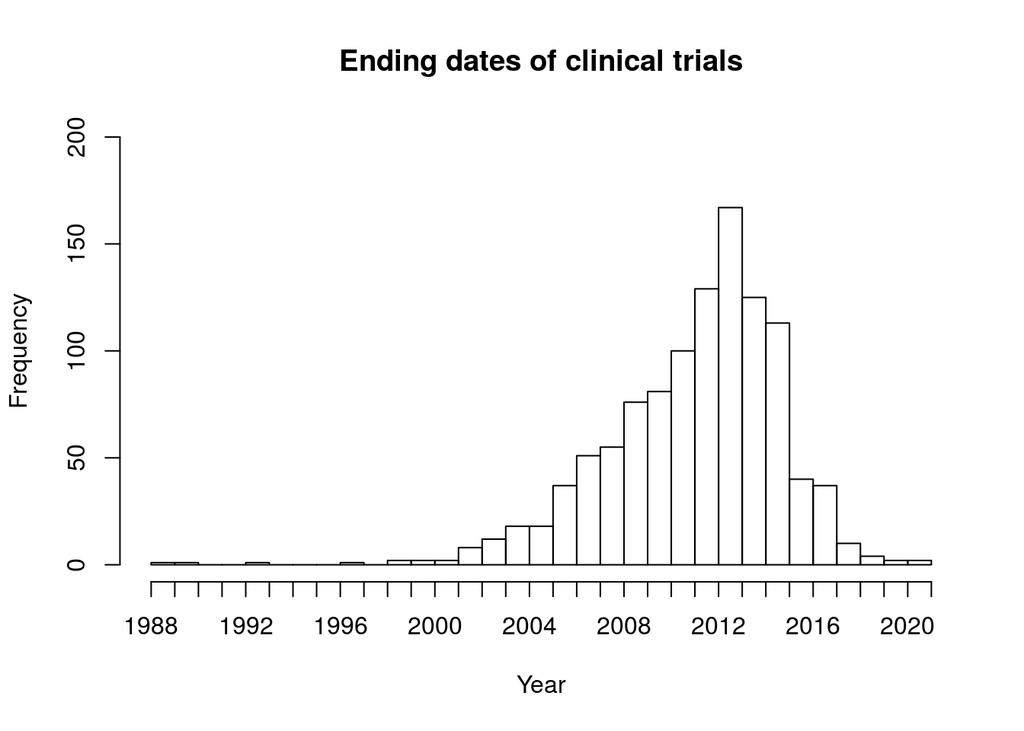

```r
library(XML)
trials = data.frame(trial = unique(na.omit(repoDB$NCT)), end_date = NA)

downloaded_trials = list.files("clinicaltrials data", pattern = ".xml")
date_vector = c()

for(t in 1:nrow(trials)){
# Check if the file is not already downloaded. If not, download it
  if(!paste(trials$trial[t], ".xml", sep = "") %in% downloaded_trials){
    fileName = curl_download(paste("https://clinicaltrials.gov/ct2/show/", trials$trial[t], "?displayxml=true", sep = ""), destfile = paste("clinicaltrials data/", trials$trial[t], ".xml", sep = ""))} else {
      fileName = paste("clinicaltrials data/", trials$trial[t], ".xml", sep = "")
      }
  xml_data = xmlParse(fileName)
  root = xmlRoot(xml_data)
  if("completion_date" %in% names(root)){
      completion_date = xmlValue(root[["completion_date"]])
      completion_date = paste(1, completion_date)
      trials$end_date[t] = as.Date(strptime(completion_date, "%d %B %Y"))
      date_vector = append(date_vector, as.Date(strptime(completion_date, "%d %B %Y")))
      } else {
      # Some trials don't have an explicit completion date, but just fizzled out. These are included below
      completion_date = xmlValue(root[["lastchanged_date"]])
      trials$end_date[t] = as.Date(strptime(completion_date, "%B %d, %Y"))
      date_vector = append(date_vector, as.Date(strptime(completion_date, "%B %d, %Y")))
    }
}

date_vector = date_vector[date_vector > as.Date(strptime("1 January 1967", "%d %B %Y"))]

hist(date_vector, breaks = "years", freq = TRUE, main = "Ending dates of clinical trials", xlab = "Year", ylim = c(0,200))
```

The completion or last update dates of the clinical trials are plotted above. Unfortunately, the data was not as clean as I would have preferred. However, the plot above should provide a rough indication.

It is clear the data is not as old as we were initially afraid of. Most of it appears to be from the last decade, with a peak around 2012. I would guess the majority of the postive cases were approved before the outcomes of these clinical trials.

It would be interesting to see whether this curve is similar as the number of publications available in PubMed. However, that is out of scope for now.

### Further analysis of RepoDB

During this experiment I saw some termination reasons for the trials which worried me, so I decided to analyze them. I think we should be careful whether we want to include all data, because some of their termination reasons do not appear to be related to lack of efficacy. However, modifying such a reference set is also a big decision, which should be discussed.

```r
termination_reasons = as.data.frame(table(na.omit(repoDB$DetailedStatus)))
termination_reasons = termination_reasons[order(-termination_reasons$Freq),]
kable(termination_reasons[1:25,], row.names = F)
```

| Var1 | Freq |
| --- | --- |
|  | 902 |
| Funding unavailable | 291 |
| Administratively complete. | 283 |
| Lack of funding | 122 |
| Low accrual | 111 |
| Slow accrual | 76 |
| low accrual | 63 |
| Temporarily stopped for assessment | 50 |
| Major revisions needed in study | 48 |
| Drug supply issues | 42 |
| Financial Sponsor requested termination | 36 |
| This study will not be written up. | 35 |
| Inadequate accrual rate | 33 |
| Poor accrual | 32 |
| Pharmaceutical co. withdrew support. Study was never activated and did not accrue any patients. | 30 |
| Trial completed prematurely. | 24 |
| Discontinued development of G3139 (oblimersen) | 20 |
| No Funding Source and Competing Trials | 20 |
| slow accrual | 18 |
| Study was terminated for business reasons. | 18 |
| due to safety concerns and lack of efficacy | 16 |
| Slow Accrual | 16 |
| Closed due to poor accrual and lack of feasibility to finish study per DSMB | 15 |
| Due to a lack of funding | 15 |
| Insufficient recruitment | 15 |

In total there are 754 termination reasons. While this is a large number, the reason appears to be a free text field, which might explain the variability. Still, if we look at the top 25 reasons, we see mostly logistical reasons, not necessarily because of a lack of efficacy. As such, I think we should be careful interpreting these negative cases.

Tareq indicated that only the negative cases with the “terminated” were used as negative cases. If we examine the reason for termination for these clinical trial, we see the follow reasons as most common.

```r
termination_reasons = as.data.frame(table(na.omit(repoDB[repoDB$status == "Terminated", "DetailedStatus"])))
termination_reasons = termination_reasons[order(-termination_reasons$Freq),]
kable(termination_reasons[1:20,], row.names = F)
```

| Var1 | Freq |
| --- | --- |
|  | 736 |
| Administratively complete. | 283 |
| Low accrual | 109 |
| Slow accrual | 70 |
| low accrual | 63 |
| Major revisions needed in study | 48 |
| This study will not be written up. | 35 |
| Inadequate accrual rate | 33 |
| Poor accrual | 32 |
| Trial completed prematurely. | 24 |
| Discontinued development of G3139 (oblimersen) | 20 |
| Lack of funding | 19 |
| Study was terminated for business reasons. | 18 |
| slow accrual | 17 |
| due to safety concerns and lack of efficacy | 16 |
| Slow Accrual | 16 |
| Closed due to poor accrual and lack of feasibility to finish study per DSMB | 15 |
| Due to a lack of funding | 15 |
| No more eligible patients | 12 |
| The study was terminated prematurely due to slow accrual. | 12 |

Furthermore, we check whether the termination reasons are unique for each of the three statuses.

```r
terminated_trials = unique(repoDB[repoDB$status == "Terminated", "DetailedStatus"])
suspended_trials = unique(repoDB[repoDB$status == "Suspended", "DetailedStatus"])
withdrawn_trials = unique(repoDB[repoDB$status == "Withdrawn", "DetailedStatus"])
print(intersect(terminated_trials, suspended_trials))
```

```
## [1] ""                    "Funding unavailable" "Lack of funding"
```

```r
print(intersect(suspended_trials, withdrawn_trials))
```

```
## [1] ""                "Lack of funding" "No funding"
```

```r
print(intersect(terminated_trials, withdrawn_trials))
```

```
##  [1] ""                     "slow enrollment"      "Slow accrual"
##  [4] "poor accrual"         "lack of funding"      "slow accrual"
##  [7] "Program discontinued" "Low accrual"          "Lack of funding"
## [10] "Poor enrollment"      "Lack of recruitment"  "Lack of accrual"
```

As can be seen, there is a small overlap between the reasons for the trials to closed. These are again mostly logistical.

When I examine the drugs in the RepoDB, I also see somethings strange. Given that it is a drug REPURPOSING database, you would expect that every drug should occur at least twice. However, this is not the case, leading to the quesion why they were included in the first place.

First, I analyse the complete repoDB set.

```r
# Only the accepted/terminated drugs
repo_drugs = as.data.frame(table(repoDB$drug_name[repoDB$status %in% c("Approved", "Terminated")]))
print(length(which(repo_drugs$Freq == 1)))
```

```
## [1] 573
```

```r
# As a fraction
print(length(which(repo_drugs$Freq == 1)) / nrow(repo_drugs))
```

```
## [1] 0.3670724
```

# Conclusion

Based on the results presented above, both the count features as well as the diversity features can be used to classify the drug-disease pairs, albeit with a bit lower performance. Excluding diseases or drug-disease pairs does not influence performance drastically, thereby ensuring we are not falling in the common pitfall described by Guney.  
A little less than 10% of the cases is consistenly misclassified, while ~90% of the cases is always correctly classified. The trials underlying the negative cases are all fairly recent; at least not as old as we were afraid of. The influence of publication bias should therefore be limited. However, the reasons for the failure of the trials appear to be logistical for a large part. Furthermore, although RepoDB should be used for drug repurposing, some drugs occur only once in it. This is at least a point for the discussion of the manuscript, but perhaps also internally.